# Domestic Flight Delays and Cancellations in the U.S. in 2008

## by Mohamed mohsen

## Dataset Overview

> In 2008, there were 7,009,728 domestic flights in the U.S. This dataset reports flights in the United States, including carriers, arrival and departure delays, and reasons for delays, for 2008. This dataset was obtained from the RITA (Research and Technology Bureau of Transportation Statistics).

## Investigation Overview

### Key Insights for the Presentation:

> 1. How many domestic flights were cancelled in 2008?
> 2. Causes of flight cancellations
> 3. Types of Flight Cancellations by Monthh
> 4. Average delay length by month
> 5. Types of Flight Cancellations by Day of Week
> 6. Average Flight Delay Length by Day of Week
> 7. Percent of Flights Delayed by Day of Week

## How many domestic flights were cancelled in 2008?

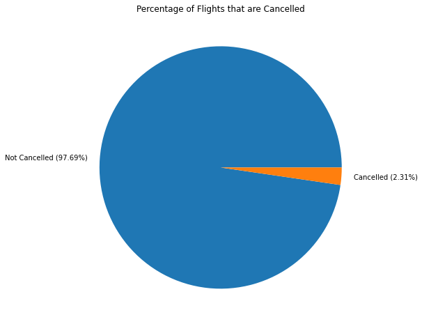

```python
df_cancelled = df['Cancelled'].value_counts().reset_index()
cancelled_percent = df_cancelled.Cancelled[1] / (df_cancelled.Cancelled[0] + df_cancelled.Cancelled[1]) * 100
not_cancelled_percent= 100-cancelled_percent
cancelled_percent =str(round(cancelled_percent, 2)) + "%"
not_cancelled_percent=str(round(not_cancelled_percent, 2)) + "%"
df_cancelled.Cancelled.plot(kind= 'pie', labels = ['Not Cancelled (' + not_cancelled_percent + ')', 'Cancelled (' + cancelled_percent + ')'], figsize=(8,8))
plt.title("Percentage of Flights that are Cancelled")
plt.ylabel("");
```

## Causes of Flight Cancellations

> The most common cause of flight cancellations is carrier, while NAS was the least.

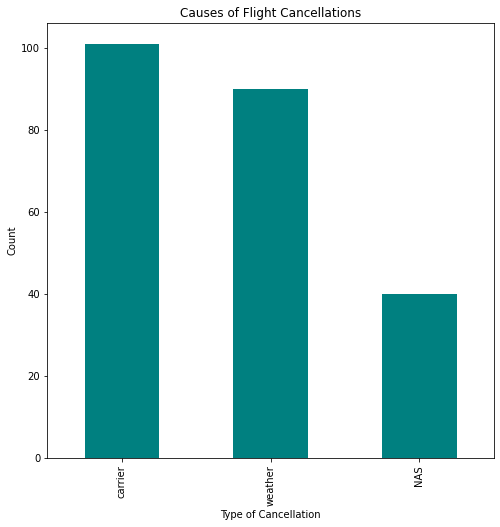

```python
df['CancellationCode'].value_counts()
df['CancellationCode'].replace({'A': 'carrier', 'B': 'weather', 'C': 'NAS'}, inplace = True)
# A = carrier, B = weather, C = NAS
df['CancellationCode'].value_counts().plot(kind= 'bar', color = 'teal', figsize=(8,8))
plt.title("Causes of Flight Cancellations")
plt.ylabel("Count")
plt.xlabel("Type of Cancellation")
plt.show();
```

## Types of Flight Cancellations by Month

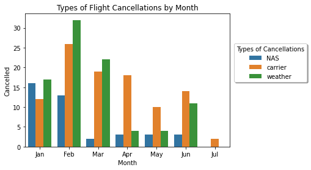

```python
df_cancelled_mv1 = df.groupby(['Month', 'CancellationCode'])['Cancelled'].count().reset_index()
df_cancelled_mv1=Sort_Dataframeby_Month(df=df_cancelled_mv1,monthcolumnname='Month')
ax = sns.barplot(data = df_cancelled_mv1, x = 'Month', y = 'Cancelled', hue = 'CancellationCode')
ax.legend(loc='upper center', bbox_to_anchor=(1.2, 0.8), shadow=True, ncol=1, title = 'Types of Cancellations')
ax.set_title('Types of Flight Cancellations by Month');
```

## Average Delay Length by Month

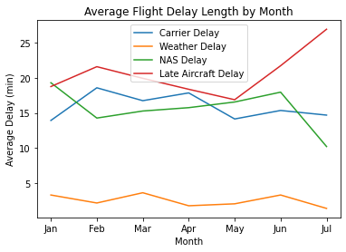

```python
df_delay_carrier = df.groupby(['Month'])['CarrierDelay'].mean().reset_index()
df_delay_weather = df.groupby(['Month'])['WeatherDelay'].mean().reset_index()
df_delay_NAS = df.groupby(['Month'])['NASDelay'].mean().reset_index()
df_delay_LateAircraft = df.groupby(['Month'])['LateAircraftDelay'].mean().reset_index()
df_delay = pd.merge(df_delay_carrier, df_delay_weather, on='Month', how='outer')
df_delay = pd.merge(df_delay, df_delay_NAS, on='Month', how='outer')
df_delay = pd.merge(df_delay, df_delay_LateAircraft, on='Month', how='outer')
df_delay=Sort_Dataframeby_Month(df=df_delay,monthcolumnname='Month')
ax = df_delay.plot(x="Month", y=["CarrierDelay", "WeatherDelay", "NASDelay", "LateAircraftDelay"], kind="line", title='Average Flight Delay Length by Month')

#plt.xticks(range(0,12),df_delay["Month"])
leg = plt.legend().get_texts()
leg[0].set_text('Carrier Delay')
leg[1].set_text('Weather Delay')
leg[2].set_text('NAS Delay')
leg[3].set_text('Late Aircraft Delay')
ax.set_ylabel('Average Delay (min)');
```

## Types of Flight Cancellations by Day of Week

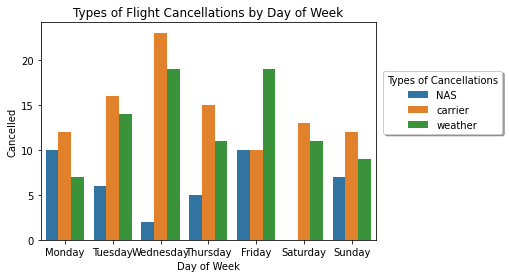

```python
df_cancelled_mv = df.groupby(['DayOfWeek', 'CancellationCode'])['Cancelled'].count().reset_index()
df_cancelled_mv=Sort_Dataframeby_Weekday(df=df_cancelled_mv,Weekdaycolumnname='DayOfWeek')
ax = sns.barplot(data = df_cancelled_mv, x = 'DayOfWeek', y = 'Cancelled', hue = 'CancellationCode')
ax.legend(loc='upper center', bbox_to_anchor=(1.2, 0.8), shadow=True, ncol=1, title = 'Types of Cancellations')
ax.set_title('Types of Flight Cancellations by Day of Week')
ax.set_xlabel('Day of Week');
```

## Average Flight Delay Length by Day of Week

> NAS and late carrier delays had the longest average delay length. Weather delays had the shortest average delay length for all days of the week.

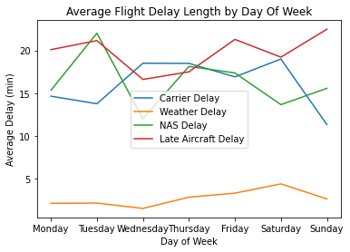

```python
df_delay_carrier = df.groupby(['DayOfWeek'])['CarrierDelay'].mean().reset_index()
df_delay_weather = df.groupby(['DayOfWeek'])['WeatherDelay'].mean().reset_index()
df_delay_NAS = df.groupby(['DayOfWeek'])['NASDelay'].mean().reset_index()
df_delay_LateAircraft = df.groupby(['DayOfWeek'])['LateAircraftDelay'].mean().reset_index()
df_delay = pd.merge(df_delay_carrier, df_delay_weather, on='DayOfWeek', how='outer')
df_delay = pd.merge(df_delay, df_delay_NAS, on='DayOfWeek', how='outer')
df_delay = pd.merge(df_delay, df_delay_LateAircraft, on='DayOfWeek', how='outer')
df_delay=Sort_Dataframeby_Weekday(df=df_delay,Weekdaycolumnname='DayOfWeek')
ax = df_delay.plot(x="DayOfWeek", y=["CarrierDelay", "WeatherDelay", "NASDelay", "LateAircraftDelay"], kind="line", title='Average Flight Delay Length by Day Of Week')
plt.xticks(range(0,7),df_delay["DayOfWeek"])
leg = plt.legend().get_texts()
leg[0].set_text('Carrier Delay')
leg[1].set_text('Weather Delay')
leg[2].set_text('NAS Delay')
leg[3].set_text('Late Aircraft Delay')
ax.set_ylabel('Average Delay (min)')
ax.set_xlabel('Day of Week');
```

## Percent of Flights Delayed by Day of Week

> Results were similar to that of types of delays by week where NAS and late Aircraft delays have the highest percentage of delays of total weekly flights and Weather has the least percentage of delays of total weekly flights.

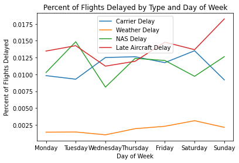

```python
# Percentage of Flights Delayed by Day of Week
flights_by_Day_of_Week = df.DayOfWeek.value_counts().reset_index()
flights_by_Day_of_Week.columns = ["Day_of_Week", "Total_Flights"]
df_delayw = df_delay.copy()
df_delayw = df_delayw[["CarrierDelay", "WeatherDelay", "NASDelay", "LateAircraftDelay"]].div(flights_by_Day_of_Week.Total_Flights, axis=0)
df_delayw.insert(0, "DayOfWeek", df_delay["DayOfWeek"], True)
ax = df_delayw.plot(x="DayOfWeek", y=["CarrierDelay", "WeatherDelay", "NASDelay", "LateAircraftDelay"], kind="line", title='Percent of Flights Delayed by Type and Day of Week')
#plt.xticks(range(0,7),df_delayw["DayOfWeek"])
leg = plt.legend().get_texts()
leg[0].set_text('Carrier Delay')
leg[1].set_text('Weather Delay')
leg[2].set_text('NAS Delay')
leg[3].set_text('Late Aircraft Delay')
ax.set_ylabel('Percent of Flights Delayed')
ax.set_xlabel('Day of Week');
```